# IODS course project

### Standardized values

To see a plot that reduces the impact of the tracking phenomenon we can make a plot of standardized values. The standardized values are obtained by subtracting the mean from the original observation then dividing by the corresponding weight measure standard deviation.

```r
# Standardise the variable bprs using the above equation
RATSL <- RATSL %>%
  group_by(Time) %>%
  mutate(stdweight = (Weight - mean(Weight))/sd(Weight)) %>%
  ungroup()

# Glimpse the data
glimpse(RATSL)
```

```
## Observations: 176
## Variables: 6
## $ ID        <fct> 1, 2, 3, 4, 5, 6, 7, 8, 9, 10, 11, 12, 13, 14, 15, 1...
## $ Group     <fct> 1, 1, 1, 1, 1, 1, 1, 1, 2, 2, 2, 2, 3, 3, 3, 3, 1, 1...
## $ WD        <fct> WD1, WD1, WD1, WD1, WD1, WD1, WD1, WD1, WD1, WD1, WD...
## $ Weight    <int> 240, 225, 245, 260, 255, 260, 275, 245, 410, 405, 44...
## $ Time      <int> 1, 1, 1, 1, 1, 1, 1, 1, 1, 1, 1, 1, 1, 1, 1, 1, 8, 8...
## $ stdweight <dbl> -1.0011429, -1.1203857, -0.9613953, -0.8421525, -0.8...
```

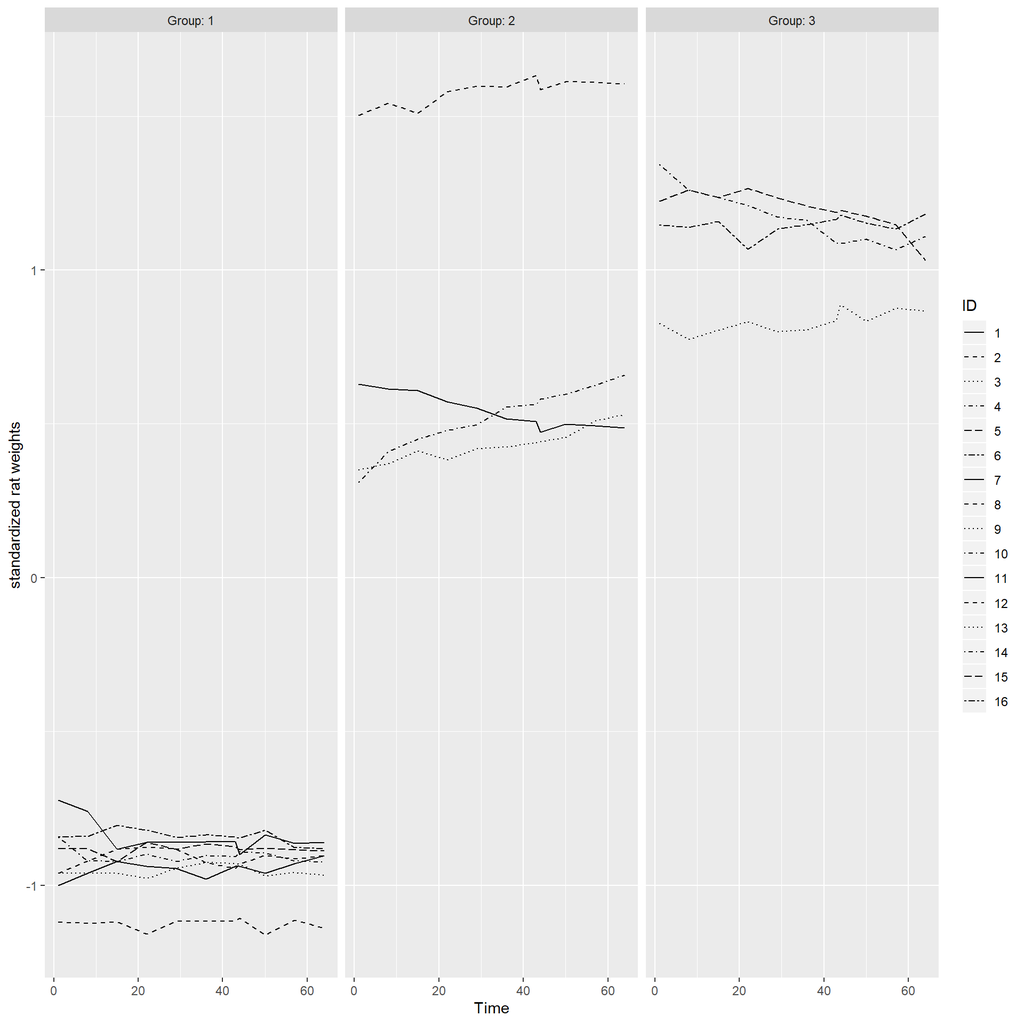

```r
# Plot again with the standardised bprs
ggplot(RATSL, aes(x = Time, y = stdweight, linetype = ID)) +
  geom_line() +
  scale_linetype_manual(values = rep(1:10, times=4)) +
  facet_grid(. ~ Group, labeller = label_both) +
  scale_y_continuous(name = "standardized rat weights")
```

### Summary Graphs

Showing average (mean) profiles for each diet group along with some indication of the variation of the observations at each time point, in this case the standard error of mean (showing the precision of the estimate of the mean).

We can see in the plot below that there is a considerable gap with no overlap between the mean profiles of the three groups suggesting significant difference between the groups with respect to the mean Weight values.

```r
# Number of weeks, baseline (week 0) included
n <- RATSL$Time %>% unique() %>% length()

# Summary data with mean and standard error of bprs by treatment and week
RATSS <- RATSL %>%
  group_by(Group, Time) %>%
  summarise( mean = mean(Weight), se = sd(Weight)/sqrt(n) ) %>%
  ungroup()

# Glimpse the data
glimpse(RATSS)
```

```
## Observations: 33
## Variables: 4
## $ Group <fct> 1, 1, 1, 1, 1, 1, 1, 1, 1, 1, 1, 2, 2, 2, 2, 2, 2, 2, 2,...
## $ Time  <int> 1, 8, 15, 22, 29, 36, 43, 44, 50, 57, 64, 1, 8, 15, 22, ...
## $ mean  <dbl> 250.625, 255.000, 254.375, 261.875, 264.625, 265.000, 26...
## $ se    <dbl> 4.589478, 3.947710, 3.460116, 4.100800, 3.333956, 3.5529...
```

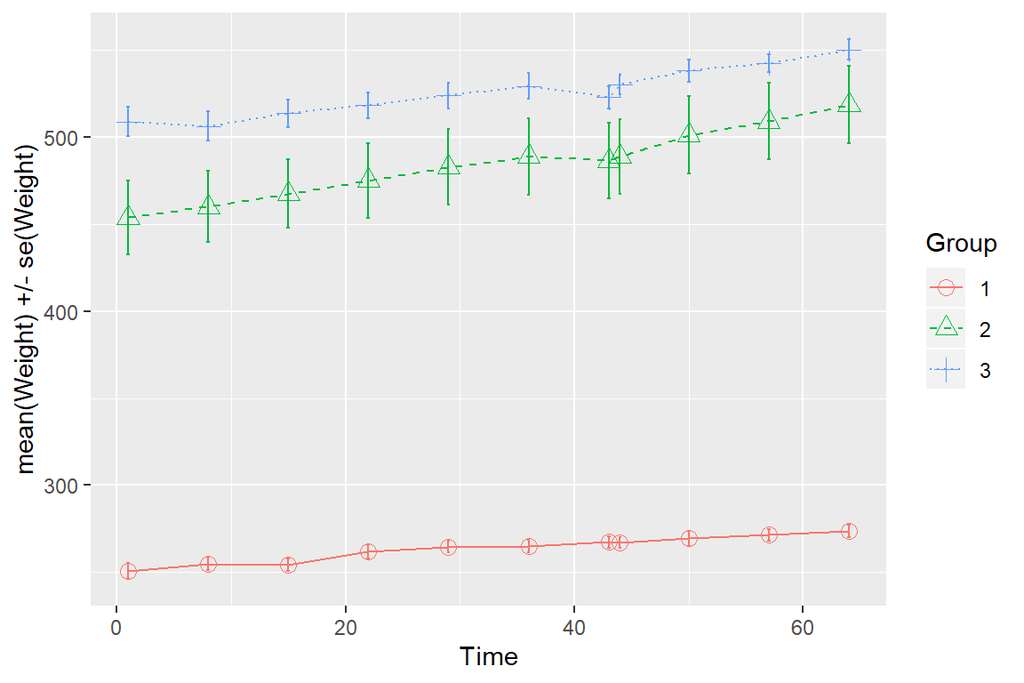

```r
# Plot the mean profiles
ggplot(RATSS, aes(x = Time, y = mean, linetype = Group, shape = Group, color = Group)) +
  geom_line() +
  scale_linetype_manual(values = c(1,2,3)) +
  geom_point(size=3) +
  scale_shape_manual(values = c(1,2,3)) +
  geom_errorbar(aes(ymin=mean-se, ymax=mean+se, linetype="1"), width=0.3) +
  theme(legend.position = "right") +
  scale_y_continuous(name = "mean(Weight) +/- se(Weight)")
```

### Side by Side box plots and summary measure

Below is an additional comparison using side-by-side box plots with the repeated measurements of weight transformed into one value, the mean, for each rat. The boxplots show the greater variabilitiy of the second and third treatment groups as well as a bit of skew. One point of group 2 seems like an outlier being far above the majority of values, a second boxplot follows with that outlier removed. It doesn’t seem like the outlier was biasing the conclusions. Even without it the groups maintain their difference and relative positions.

```r
# Create a summary data by treatment and subject with mean as the summary variable
RATSLSum <- RATSL %>%
  group_by(Group, ID) %>%
  summarise( mean=mean(Weight) ) %>%
  ungroup()

# Glimpse the data
glimpse(RATSLSum)
```

```
## Observations: 16
## Variables: 3
## $ Group <fct> 1, 1, 1, 1, 1, 1, 1, 1, 2, 2, 2, 2, 3, 3, 3, 3
## $ ID    <fct> 1, 2, 3, 4, 5, 6, 7, 8, 9, 10, 11, 12, 13, 14, 15, 16
## $ mean  <dbl> 261.0909, 237.6364, 260.1818, 266.5455, 269.4545, 274.72...
```

```r
summary(RATSLSum)
```

```
##  Group       ID          mean
##  1:8   1      : 1   Min.   :237.6
##  2:4   2      : 1   1st Qu.:266.3
##  3:4   3      : 1   Median :357.8
##        4      : 1   Mean   :384.5
##        5      : 1   3rd Qu.:503.1
##        6      : 1   Max.   :590.5
##        (Other):10
```

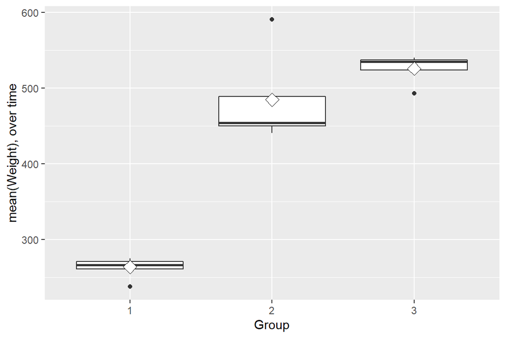

```r
# Draw a boxplot of the mean versus treatment
ggplot(RATSLSum, aes(x = Group, y = mean)) +
  geom_boxplot() +
  stat_summary(fun.y = "mean", geom = "point", shape=23, size=4, fill = "white") +
  scale_y_continuous(name = "mean(Weight), over time")
```

```r
# Create a new data by filtering the outlier
RATSLSum2 <- filter(RATSLSum, RATSLSum$mean < 590)


# Glimpse the data
glimpse(RATSLSum2)
```

```
## Observations: 15
## Variables: 3
## $ Group <fct> 1, 1, 1, 1, 1, 1, 1, 1, 2, 2, 2, 3, 3, 3, 3
## $ ID    <fct> 1, 2, 3, 4, 5, 6, 7, 8, 9, 10, 11, 13, 14, 15, 16
## $ mean  <dbl> 261.0909, 237.6364, 260.1818, 266.5455, 269.4545, 274.72...
```

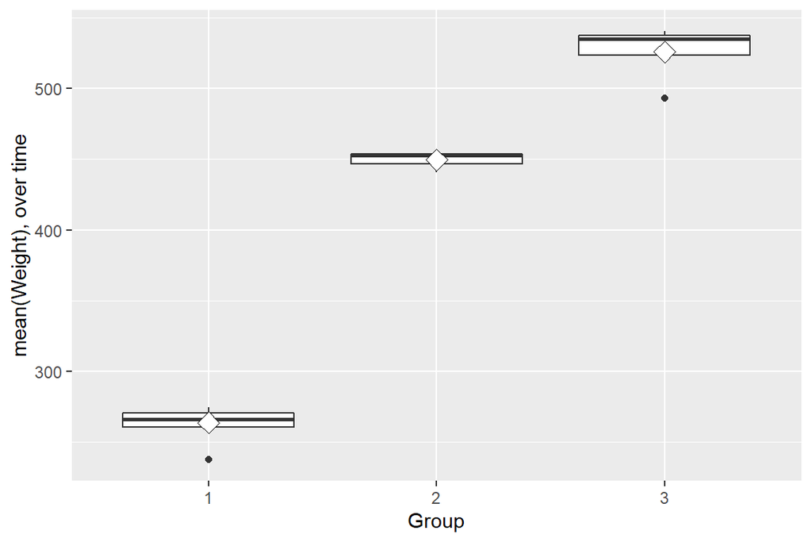

```r
# Draw a boxplot of the mean versus treatment
ggplot(RATSLSum2, aes(x = Group, y = mean)) +
  geom_boxplot() +
  stat_summary(fun.y = "mean", geom = "point", shape=23, size=4, fill = "white") +
  scale_y_continuous(name = "mean(Weight), over time")
```

### A formal test for difference

Chapter 8 of MABS included a t-test but our dataset has three groups.

The Anova table below using a baseline shows us no significant difference between the groups so it would seem that the difference between rat weights is mostly due to their starting weights rather than the diet having an impact. This is not something we could tell from the previous boxplots of the summary measure analysis.

```r
RATS <- read.csv("https://raw.githubusercontent.com/KimmoVehkalahti/MABS/master/Examples/data/rats.txt", sep = "\t")

# Adding the baseline from the original data as a new variable to the summary data
RATSLSum3 <- RATSLSum %>%
  mutate(baseline = RATS$WD1)

# Fitting the linear model with the mean as the response/target and baseline + treatment as the response from the RATSL8S1
fit <- lm(mean ~ baseline + Group, data = RATSLSum3)

# Compute the analysis of variance table for the fitted model with anova() and pay close attention to the significance of baseline
anova(fit)
```

```
## Analysis of Variance Table
##
## Response: mean
##           Df Sum Sq Mean Sq   F value    Pr(>F)
## baseline   1 252125  252125 2237.0655 5.217e-15 ***
## Group      2    726     363    3.2219   0.07586 .
## Residuals 12   1352     113
## ---
## Signif. codes:  0 '***' 0.001 '**' 0.01 '*' 0.05 '.' 0.1 ' ' 1
```

### Missing values

Chapter 8 of MABS for IODS includes a section on dealign with missing values but the following check indicates that our data has no missing values.

```r
summary(complete.cases(RATSL))
```

```
##    Mode    TRUE
## logical     176
```

## 2. Analyses of Chapter 9 of MABS using the BPRS data.

A group of 40 men where randomly put into two different groups that were given different treatments and tested over 8 weeks (week 0 was before treatment began) for their Brief Psychiatric Rating Scale (BPRS) score which is used to evaluate patients suspected of having schizophrenia.

We’re looking to determine the explanatory variables most associated with the change in BPRS. The below analysis is more complete and more appropriate for longitudinal data than section 1 above.

### Graphs or analysis results

### Interpretations

```r
BPRSL <- read.csv("data/BPRSL.csv", sep = ",")

BPRSL$treatment <- factor(BPRSL$treatment)
BPRSL$subject <- factor(BPRSL$subject)

str(BPRSL)
```

```
## 'data.frame':    360 obs. of  5 variables:
##  $ treatment: Factor w/ 2 levels "1","2": 1 1 1 1 1 1 1 1 1 1 ...
##  $ subject  : Factor w/ 20 levels "1","2","3","4",..: 1 2 3 4 5 6 7 8 9 10 ...
##  $ weeks    : Factor w/ 9 levels "week0","week1",..: 1 1 1 1 1 1 1 1 1 1 ...
##  $ bprs     : int  42 58 54 55 72 48 71 30 41 57 ...
##  $ week     : int  0 0 0 0 0 0 0 0 0 0 ...
```

```r
summary(complete.cases(BPRSL))
```

```
##    Mode    TRUE
## logical     360
```

### Graphical look at the data

```r
# Check the dimensions of the data
dim(BPRSL)
```

```
## [1] 360   5
```

```r
# Plot the BPRSL data
ggplot(BPRSL, aes(x = week, y = bprs, group = subject)) +
  geom_text(aes(label = treatment)) +
  scale_x_continuous(name = "Week") +
  scale_y_continuous(name = "BPRS")
```

[output not shown]

### Fitting Linear Mixed Models to the BPRS data

Looking at the Pr(>|t|) values below it seems that while the bprs score decreases as the weeks progress, the treatment group has no significant effect.

```r
# create a regression model RATS_reg
BPRS_reg <- lm(bprs ~ week + treatment, BPRSL)

# print out a summary of the model
summary(BPRS_reg)
```

```
##
## Call:
## lm(formula = bprs ~ week + treatment, data = BPRSL)
##
## Residuals:
##     Min      1Q  Median      3Q     Max
## -22.454  -8.965  -3.196   7.002  50.244
##
## Coefficients:
##             Estimate Std. Error t value Pr(>|t|)
## (Intercept)  46.4539     1.3670  33.982   <2e-16 ***
## week         -2.2704     0.2524  -8.995   <2e-16 ***
## treatment2    0.5722     1.3034   0.439    0.661
## ---
## Signif. codes:  0 '***' 0.001 '**' 0.01 '*' 0.05 '.' 0.1 ' ' 1
##
## Residual standard error: 12.37 on 357 degrees of freedom
## Multiple R-squared:  0.1851, Adjusted R-squared:  0.1806
## F-statistic: 40.55 on 2 and 357 DF,  p-value: < 2.2e-16
```

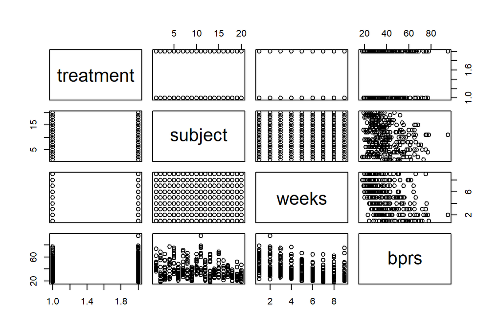

```r
# a scatterplot matrix of the repeated measures of bprs
pairs(BPRSL[,1:4])
```

### Random Intercept and Random Slope Models

This kind of model allows the linear regression fits for each individual to differ in intercept, but also in slope making it possible to account for individual differences in the subjects changing BPRS and also the effect of time.

The models below are compared using Anova. Neither one shows a significant impact of treatment on bprs.

```r
library(lme4)
# create a random intercept and random slope models
BPRS_ref <- lmer(bprs ~ week + treatment + (1 | subject), data = BPRSL, REML = FALSE)
BPRS_ref1 <- lmer(bprs ~ week + treatment + (week | subject), data = BPRSL, REML = FALSE)

# print a summary of the models
summary(BPRS_ref)
```

```
## Linear mixed model fit by maximum likelihood  ['lmerMod']
## Formula: bprs ~ week + treatment + (1 | subject)
##    Data: BPRSL
##
##      AIC      BIC   logLik deviance df.resid
##   2748.7   2768.1  -1369.4   2738.7      355
##
## Scaled residuals:
##     Min      1Q  Median      3Q     Max
## -3.0481 -0.6749 -0.1361  0.4813  3.4855
##
## Random effects:
##  Groups   Name        Variance Std.Dev.
##  subject  (Intercept)  47.41    6.885
##  Residual             104.21   10.208
## Number of obs: 360, groups:  subject, 20
##
## Fixed effects:
##             Estimate Std. Error t value
## (Intercept)  46.4539     1.9090  24.334
## week         -2.2704     0.2084 -10.896
## treatment2    0.5722     1.0761   0.532
##
## Correlation of Fixed Effects:
##            (Intr) week
## week       -0.437
## treatment2 -0.282  0.000
```

```r
summary(BPRS_ref1)
```

```
## Linear mixed model fit by maximum likelihood  ['lmerMod']
## Formula: bprs ~ week + treatment + (week | subject)
##    Data: BPRSL
##
##      AIC      BIC   logLik deviance df.resid
##   2745.4   2772.6  -1365.7   2731.4      353
##
## Scaled residuals:
##     Min      1Q  Median      3Q     Max
## -2.8919 -0.6194 -0.0691  0.5531  3.7977
##
## Random effects:
##  Groups   Name        Variance Std.Dev. Corr
##  subject  (Intercept) 64.8222  8.0512
##           week         0.9609  0.9803   -0.51
##  Residual             97.4304  9.8707
## Number of obs: 360, groups:  subject, 20
##
## Fixed effects:
##             Estimate Std. Error t value
## (Intercept)  46.4539     2.1052  22.066
## week         -2.2704     0.2977  -7.626
## treatment2    0.5722     1.0405   0.550
##
## Correlation of Fixed Effects:
##            (Intr) week
## week       -0.582
## treatment2 -0.247  0.000
```

```r
# perform an ANOVA test on the two models
anova(BPRS_ref1, BPRS_ref)
```

```
## Data: BPRSL
## Models:
## BPRS_ref: bprs ~ week + treatment + (1 | subject)
## BPRS_ref1: bprs ~ week + treatment + (week | subject)
##           Df    AIC    BIC  logLik deviance  Chisq Chi Df Pr(>Chisq)
## BPRS_ref   5 2748.7 2768.1 -1369.4   2738.7
## BPRS_ref1  7 2745.4 2772.6 -1365.7   2731.4 7.2721      2    0.02636 *
## ---
## Signif. codes:  0 '***' 0.001 '**' 0.01 '*' 0.05 '.' 0.1 ' ' 1
```

```r
# draw the plot of BPRSL with the bprs values
ggplot(BPRSL, aes(x = week, y = bprs, group = subject)) +
  geom_text(aes(label = treatment)) +
  scale_x_continuous(name = "Week") +
  scale_y_continuous(name = "BPRS")
```

[output not shown]

```r
# create a random intercept and random slope model with the interaction
BPRS_ref2 <- lmer(bprs ~ week + treatment + (week | subject), data = BPRSL, REML = FALSE)

# print a summary of the model
summary(BPRS_ref2)
```

```
## Linear mixed model fit by maximum likelihood  ['lmerMod']
## Formula: bprs ~ week + treatment + (week | subject)
##    Data: BPRSL
##
##      AIC      BIC   logLik deviance df.resid
##   2745.4   2772.6  -1365.7   2731.4      353
##
## Scaled residuals:
##     Min      1Q  Median      3Q     Max
## -2.8919 -0.6194 -0.0691  0.5531  3.7977
##
## Random effects:
##  Groups   Name        Variance Std.Dev. Corr
##  subject  (Intercept) 64.8222  8.0512
##           week         0.9609  0.9803   -0.51
##  Residual             97.4304  9.8707
## Number of obs: 360, groups:  subject, 20
##
## Fixed effects:
##             Estimate Std. Error t value
## (Intercept)  46.4539     2.1052  22.066
## week         -2.2704     0.2977  -7.626
## treatment2    0.5722     1.0405   0.550
##
## Correlation of Fixed Effects:
##            (Intr) week
## week       -0.582
## treatment2 -0.247  0.000
```

```r
# perform an ANOVA test on the two models
anova(BPRS_ref2, BPRS_ref1)
```

```
## Data: BPRSL
## Models:
## BPRS_ref2: bprs ~ week + treatment + (week | subject)
## BPRS_ref1: bprs ~ week + treatment + (week | subject)
##           Df    AIC    BIC  logLik deviance Chisq Chi Df Pr(>Chisq)
## BPRS_ref2  7 2745.4 2772.6 -1365.7   2731.4
## BPRS_ref1  7 2745.4 2772.6 -1365.7   2731.4     0      0          1
```

```r
# draw the plot of BPRSL with the bprs values
ggplot(BPRSL, aes(x = week, y = bprs, group = subject)) +
  geom_text(aes(label = treatment)) +
  scale_x_continuous(name = "Week") +
  scale_y_continuous(name = "BPRS")
```

[output not shown]

```r
# Create a vector of the fitted values
Fitted <- fitted(BPRS_ref2)

# Create a new column fitted to BPRSL
BPRSL <- BPRSL %>%
  mutate(Fitted)

# draw the plot of BPRSL with the Fitted values of bprs
ggplot(BPRSL, aes(x = week, y = bprs, group = subject)) +
  geom_text(aes(label = treatment)) +
  scale_x_continuous(name = "Week") +
  scale_y_continuous(name = "BPRS")
```

[output not shown]